# Projekt

- Show All Code
- Hide All Code
- View Source

Author

Aneta Miniberger, Tomáš Podivínský

# 1 Projekt: Stochastická analýza akcií společnosti Colt CZ Group SE

## 1.1 Motivace projektu

Cílem projektu je analyzovat vývoj akcií společnosti **Colt CZ Group SE.** Jedná se o klíčového zástupce zbrojního průmyslu, jehož tržní hodnota je v posledních letech silně ovlivněna válečným konfliktem na Ukrajině.pomocí klasických i rozšířených stochastických modelů. Datový soubor obsahuje denní uzavírací ceny akcie `CZG.PR` získané z Yahoo Finance. Sledované období začíná 24. února 2022, tedy dnem začátku války na Ukrajině, která měla výrazný dopad na evropský zbrojní sektor.

```r
required_packages <- c(
  "quantmod", "moments", "nortest", "ggplot2",
  "dplyr", "tibble", "knitr", "MASS",
  "tidyverse", "zoo", "lubridate", "scales"
)

for(pkg in required_packages){
  if(!require(pkg, character.only = TRUE)){
    install.packages(pkg)
    library(pkg, character.only = TRUE)
  }
}
```

# 2 Pomocné funkce

```r
simulate_price_paths <- function(
  prices,
  dates,
  M = 1000,
  return_generator,
  x0 = NULL
){

  N <- length(prices)

  if(is.null(x0)){
    x0 <- as.numeric(prices[1])
  }

  sim_returns <- return_generator(M, N)

  sim_prices <- matrix(NA, nrow = M, ncol = N)
  sim_prices[,1] <- x0

  for(i in 1:M){
    sim_prices[i,2:N] <- x0 * exp(cumsum(sim_returns[i,]))
  }

  mean_traj <- apply(sim_prices, 2, mean)

  lower_ci <- apply(sim_prices, 2, quantile, probs = 0.025)
  upper_ci <- apply(sim_prices, 2, quantile, probs = 0.975)

  summary_df <- tibble(
    Date = dates,
    Real = as.numeric(prices),
    Mean = mean_traj,
    Lower = lower_ci,
    Upper = upper_ci
  )

  sample_paths <- sample(1:M, min(100, M))

  paths_df <- purrr::map_dfr(
    sample_paths,
    \(i) tibble(
      Date = dates,
      Price = sim_prices[i,],
      Path = as.factor(i)
    )
  )

  list(
    sim_prices = sim_prices,
    summary_df = summary_df,
    paths_df = paths_df
  )
}

plot_simulation <- function(sim_obj, title = ""){

  ggplot() +

    geom_line(
      data = sim_obj$paths_df,
      aes(Date, Price, group = Path),
      color = "grey70",
      alpha = 0.35,
      linewidth = 0.25
    ) +

    geom_ribbon(
      data = sim_obj$summary_df,
      aes(Date, ymin = Lower, ymax = Upper),
      fill = "red",
      alpha = 0.18
    ) +

    geom_line(
      data = sim_obj$summary_df,
      aes(Date, Mean),
      color = "red",
      linewidth = 0.9,
      linetype = 2
    ) +

    geom_line(
      data = sim_obj$summary_df,
      aes(Date, Real),
      color = "#1B1B1B",
      linewidth = 0.9
    ) +

    theme_minimal(base_size = 13) +

    theme(
      plot.title = element_text(face = "bold"),
      panel.grid.minor = element_blank()
    ) +

    labs(
      title = title,
      x = "",
      y = "Cena akcie (CZK)"
    ) +
    ylim(0, 3000)
}
```

# 3 Načtení dat

```r
symbol <- "CZG.PR"

start_date <- "2022-02-24"
end_date <- Sys.Date()

getSymbols(
  symbol,
  src = "yahoo",
  from = start_date,
  to = end_date
)

prices <- Cl(get(symbol))

df <- prices |>
  as.data.frame() |>
  rownames_to_column("Date") |>
  mutate(
    Date = as.Date(Date)
  ) |>
  rename(
    Price = CZG.PR.Close
  ) |>
  mutate(
    Returns = c(NA, diff(log(Price))),
    Year = lubridate::year(Date)
  )
returns <- na.omit(df$Returns)
```

# 4 Exploratorní analýza

## 4.1 Vývoj ceny akcie

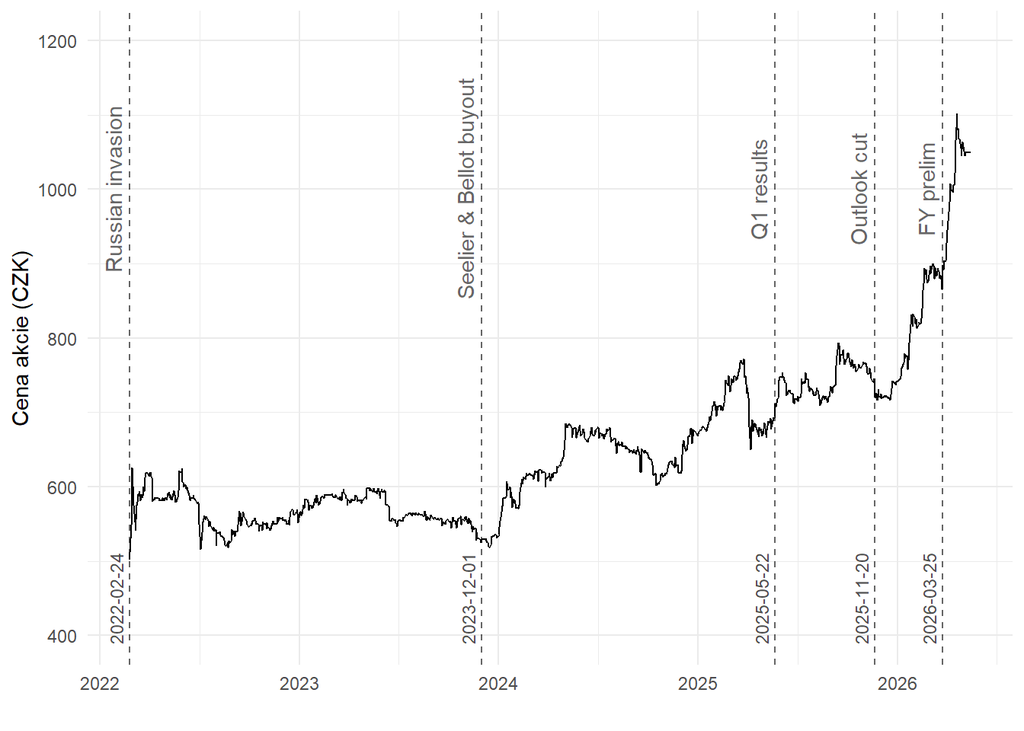

```r
events <- data.frame(
  date = as.Date(c(
    "2025-11-20",
    "2025-05-22",
    "2026-03-25",
    "2022-02-24",
    "2023-12-01"
  )),
  label = c(
    "Outlook cut",
    "Q1 results",
    "FY prelim",
    "Russian invasion",
    "Seelier & Bellot buyout"
  )
)

ggplot(df, aes(Date, Price)) +
  geom_line() +
  geom_vline(data = events, aes(xintercept = date),
         linetype = "dashed", alpha = 0.6) +
  geom_text(data = events,
        aes(x = date, y = 1000, label = label),
        angle = 90, vjust = -0.5, alpha = 0.6) +
  geom_text(data = events,
        aes(x = date, y = 450, label = as.character(date)),
        angle = 90, vjust = -0.5, size = 3, alpha = 0.7) +
  theme_minimal() +
  ylim(400, 1200) +
  labs(y = "Cena akcie (CZK)", x = "")
```

## 4.2 Logaritmické výnosy

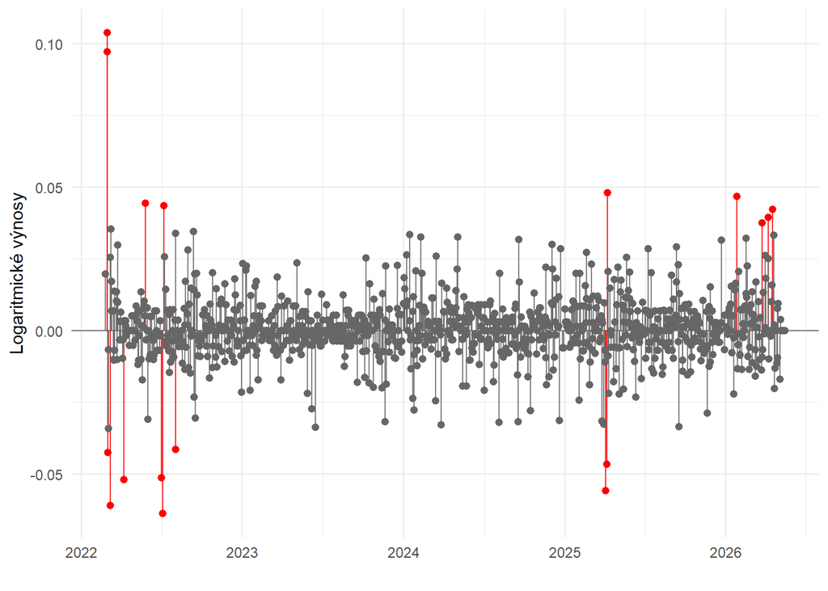

```r
threshold <- 3 * sd(df$Returns, na.rm = TRUE)

df <- df |>
  mutate(
    Jump = abs(Returns) > threshold
  )

ggplot(df, aes(Date, Returns)) +

  geom_hline(yintercept = 0,
             color = "grey50") +

  geom_segment(aes(
    xend = Date,
    y = 0,
    yend = Returns,
    color = Jump
  ),
  linewidth = 0.4,
  alpha = 0.8) +

  geom_point(aes(color = Jump),
             size = 1.8) +
  scale_color_manual(values = c(
    "FALSE" = "grey40",
    "TRUE" = "red"
  )) +

  theme_minimal() +

  theme(
    legend.position = "none"
  ) +

  labs(
    y = "Logaritmické výnosy",
    x = ""
  )
```

## 4.3 Ověření předpokladů - normalita a nezávislost

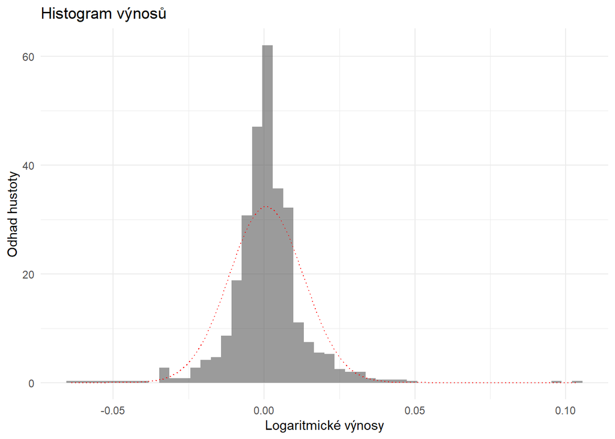

```r
ggplot(df, aes(Returns)) +
  geom_histogram(aes(y = ..density..), bins = 50, alpha = 0.6) +
  stat_function(fun = dnorm,
                args = list(mean = mean(df$Returns, na.rm=TRUE),
                            sd = sd(df$Returns, na.rm=TRUE)),
                col = "red", lty = 3) +
  ggtitle("Histogram výnosů") +
  labs(x = "Logaritmické výnosy", y = "Odhad hustoty") +
  theme_minimal()
```

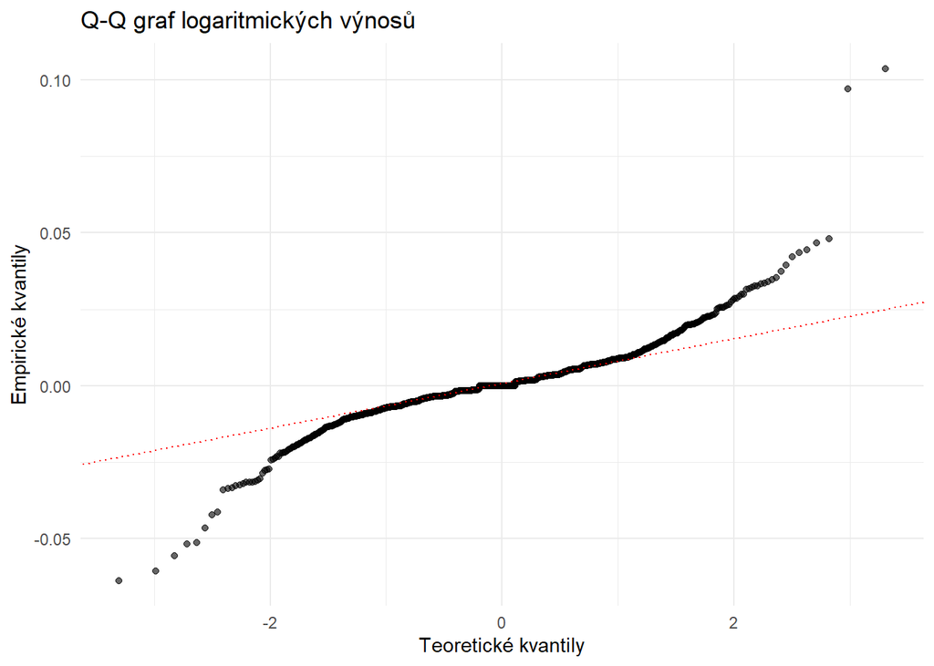

```r
# qq plot
ggplot(df, aes(sample = Returns)) +
  stat_qq(alpha = 0.6) +
  stat_qq_line(color = "red", lty = 3) +
  theme_minimal() +
  labs(
    title = "Q-Q graf logaritmických výnosů",
    x = "Teoretické kvantily",
    y = "Empirické kvantily"
  )
```

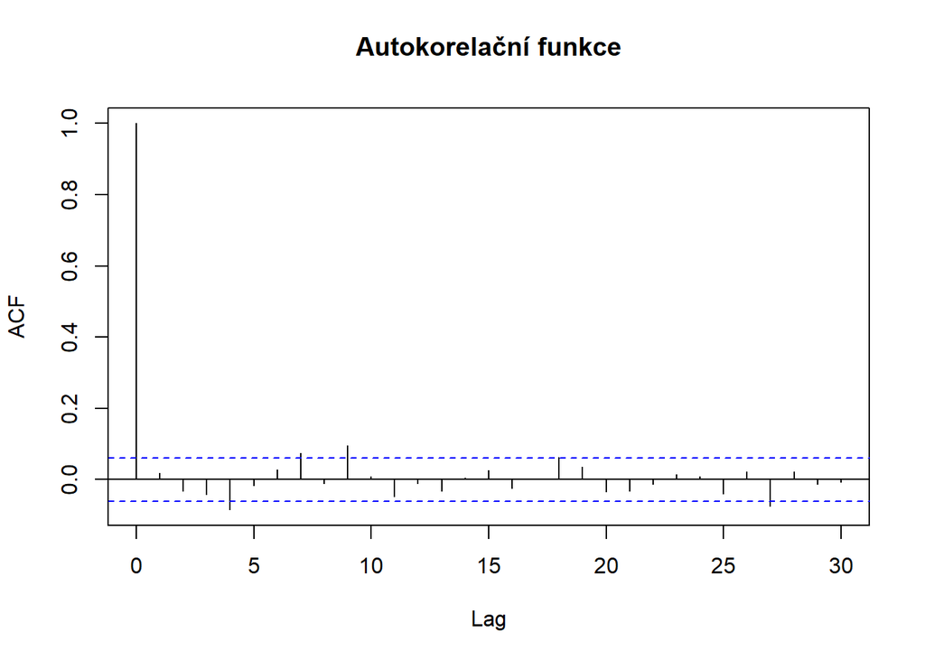

```r
acf(na.omit(df$Returns), main="Autokorelační funkce")
```

Výsledky ukazují, že logaritmické výnosy nejsou dokonale normálně rozdělené. To je typický jev u finančních dat, kde se často objevují těžší chvosty a extrémní pozorování.

# 5 Geometrický Brownův pohyb

Základní model vývoje cen finančního aktiva je geometrický Brownův pohyb (GBM), který předpokládá konstantní drift a konstantní volatilitu. Model je definován stochastickou diferenciální rovnicí

$$\frac{dX_t}{X_t} = \mu\,dt + \sigma\,dW_t,$$

kde $X_t$ je cena aktiva v čase $t$, $\mu$ je driftový parametr, $\sigma$ volatilita a $W_t$ standardní Brownův pohyb.

Řešení této rovnice má tvar

$$X_t = X_0 \exp\left(\left(\mu - \frac{1}{2}\sigma^2\right)t + \sigma W_t\right).$$

Model implikuje log-normální rozdělení cen a konstantní volatilitu v čase, což představuje základní referenční rámec pro složitější modely finančních trhů.

## 5.1 Odhad parametrů

```r
dt <- 1/252

R_bar <- mean(returns)
S_sq <- var(returns)

mu_hat <- (R_bar / dt) + (S_sq / (2 * dt))
sigma_hat <- sqrt(S_sq / dt)

params_tbl <- tibble(
  Parametr =  c("$\\mu$", "$\\sigma$"),
  Hodnota = c(mu_hat, sigma_hat)
)

knitr::kable(
  params_tbl,
  digits = 4,
  caption = "Odhady parametrů GBM"
)
```

Odhady parametrů GBM

| Parametr | Hodnota |
| --- | --- |
| $\mu$ | 0.1952 |
| $\sigma$ | 0.1955 |

## 5.2 Simulace trajektorií

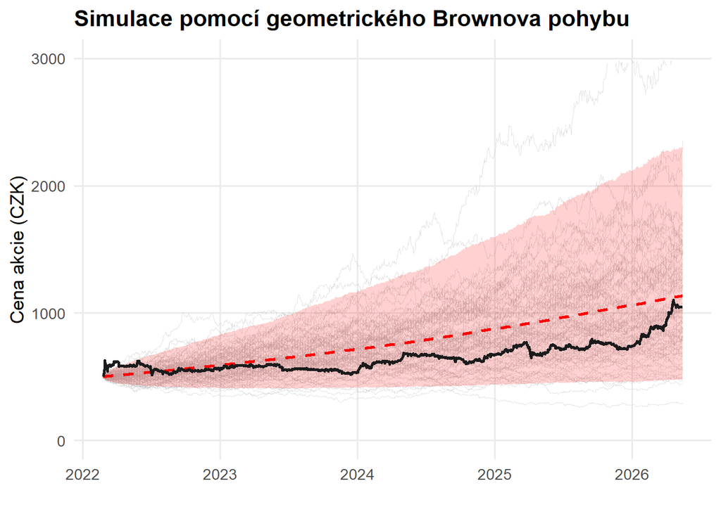

```r
gbm_returns <- function(M, N, mu, sigma, dt = 1/252){

  matrix(
    rnorm(
      M * (N - 1),
      mean = (mu - 0.5 * sigma^2) * dt,
      sd = sigma * sqrt(dt)
    ),
    nrow = M
  )
}

gbm_sim <- simulate_price_paths(
  prices = df$Price,
  dates = df$Date,
  M = 5000,

  return_generator = function(M, N){
    gbm_returns(
      M = M,
      N = N,
      mu = mu_hat,
      sigma = sigma_hat
    )
  }
)

plot_simulation(
  gbm_sim,
  "Simulace pomocí geometrického Brownova pohybu"
)
```

# 6 Rolling volatilita

V následujícím modelu nahrazuje konstantní volatilitu $\sigma$ časově závislá funkce $\sigma_t$, která umožňuje zachytit dynamickou proměnlivost finančních trhů. Namísto předpokladu konstantní variance se tedy uvažuje lokálně adaptivní volatilita odhadovaná na základě pohyblivého okna historických výnosů.

Typicky je rolling volatilita definována jako

$$\sigma_t = \sqrt{\frac{1}{k-1}\sum_{i=t-k+1}^{t} (r_i - \bar{r}_t)^2},$$

kde $k$ označuje velikost okna, $r_i$ jsou logaritmické výnosy a $\bar{r}_t$ jejich průměr v daném okně.

Tento přístup umožňuje modelovat volatilitu jako lokálně stacionární proces, který lépe reaguje na období zvýšené nebo snížené tržní nejistoty.

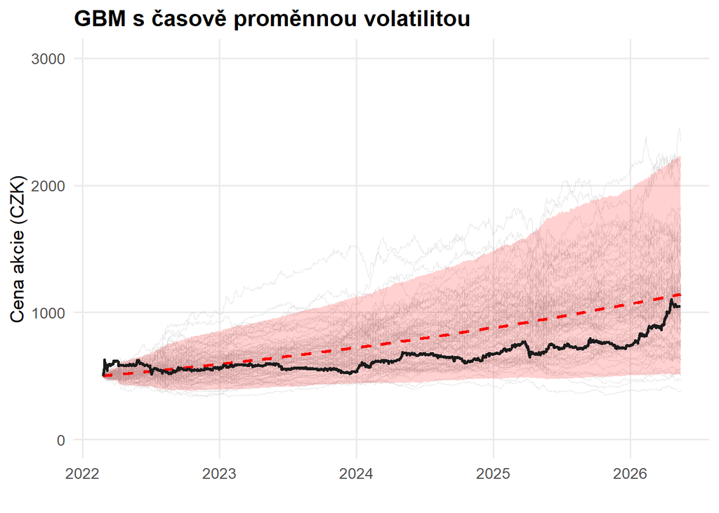

```r
roll_sd <- rollapply(
  returns,
  width = 30,
  FUN = sd,
  fill = NA,
  align = "right"
)

rolling_sigma <- roll_sd / sqrt(dt)

rolling_sigma[is.na(rolling_sigma)] <- mean(
  rolling_sigma,
  na.rm = TRUE
)

rolling_gbm_returns <- function(
  M,
  N,
  mu,
  sigma_vector,
  dt = 1/252
){

  out <- matrix(NA, nrow = M, ncol = N - 1)

  for(t in 1:(N - 1)){

    sigma_t <- sigma_vector[t]

    out[,t] <- rnorm(
      M,
      mean = (mu - 0.5 * sigma_t^2) * dt,
      sd = sigma_t * sqrt(dt)
    )
  }

  out
}

rolling_sim <- simulate_price_paths(
  prices = df$Price,
  dates = df$Date,
  M = 5000,

  return_generator = function(M, N){
    rolling_gbm_returns(
      M = M,
      N = N,
      mu = mu_hat,
      sigma_vector = rolling_sigma
    )
  }
)

plot_simulation(
  rolling_sim,
  "GBM s časově proměnnou volatilitou"
)
```

# 7 Mertonův jump-diffusion model

Mertonův model rozšiřuje geometrický Brownův pohyb o náhodné skoky.

SDR je ve tvaru

$$\frac{dS(t)}{S(t)} = ( \mu - \lambda \kappa ) \, dt + \sigma \, dW(t) + \, (Y - 1) \, dN(t).$$

Řešení má tvar

$$S(t) = S(0) \cdot \exp \left[ \left( \mu - \lambda \kappa - \frac{1}{2}\sigma^2 \right) t + \sigma W(t) + \sum_{i=1}^{N(t)} \ln(Y_i) \right].$$

Význam přidaných parametrů:

$$\begin{aligned}
&N(t) &&\text{Poissonův proces} \\
&\lambda &&\text{průměrný počet skoků za jednotku času} \\
&Y - 1 &&\text{procentuální změna ceny akcie, pokud nastane skok} \\
&\kappa &&=E(Y - 1)
\end{aligned}$$

Model je vhodný zejména pro zachycení prudkých pohybů trhu, které klasický GBM neumí dostatečně popsat.

## 7.1 Detekce skoků

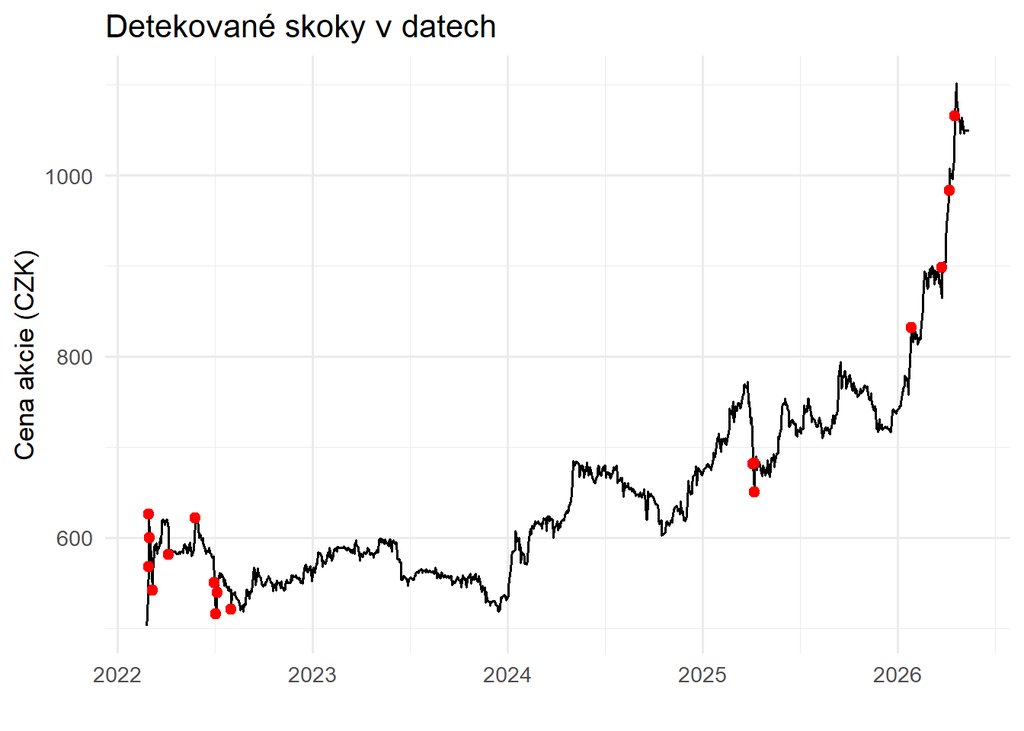

```r
threshold <- 3 * sd(returns)

df <- df |>
  mutate(
    Jump = abs(Returns) > threshold
  )

ggplot(df, aes(Date, Price)) +

  geom_line(color = "black") +

  geom_point(
    data = subset(df, Jump == TRUE),
    aes(Date, Price),
    color = "red",
    size = 2
  ) +

  theme_minimal(base_size = 13) +

  labs(
    title = "Detekované skoky v datech",
    x = "",
    y = "Cena akcie (CZK)"
  )
```

## 7.2 Odhad parametrů modelu

```r
merton_params <- df |>
  summarise(
    lambda_hat = mean(Jump, na.rm = TRUE),
    mu_hat = mean(Returns[!Jump], na.rm = TRUE) / dt,
    sigma_hat = sd(Returns[!Jump], na.rm = TRUE) / sqrt(dt),
    mu_J_hat = mean(Returns[Jump], na.rm = TRUE),
    sigma_J_hat = sd(Returns[Jump], na.rm = TRUE)
  )

merton_params_tbl <- tibble(
  Parametr = c("$\\lambda$", "$\\mu$", "$\\sigma$", "$\\mu_J$", "$\\sigma_J$"),
  Hodnota = c(
    merton_params$lambda_hat,
    merton_params$mu_hat,
    merton_params$sigma_hat,
    merton_params$mu_J_hat,
    merton_params$sigma_J_hat
  )
)

knitr::kable(
  merton_params_tbl,
  escape = FALSE,
  digits = 5,
  caption = "Odhady parametrů Mertonova modelu"
)
```

Odhady parametrů Mertonova modelu

| Parametr | Hodnota |
| --- | --- |
| $\lambda$ | 0.01610 |
| $\mu$ | 0.15745 |
| $\sigma$ | 0.15959 |
| $\mu_J$ | 0.00522 |
| $\sigma_J$ | 0.05850 |

## 7.3 Simulace Mertonova modelu

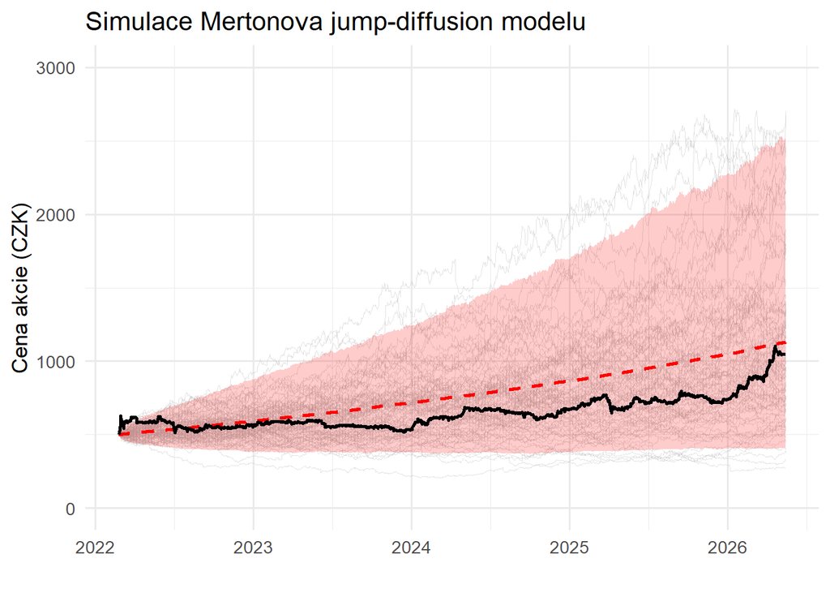

```r
generate_jumps <- function(
  T,
  dt,
  x0,
  mu,
  sigma,
  lambda,
  mu_j,
  sigma_j
){

  t <- seq(0, T, by = dt)

  n <- length(t) - 1

  W <- c(0, cumsum(rnorm(n, sd = sqrt(dt))))

  N_jump <- rpois(n, lambda = lambda * dt)

  Y <- rnorm(n, mean = mu_j, sd = sigma_j)

  jumps <- c(0, cumsum(Y * N_jump))

  kappa <- exp(mu_j + 0.5 * sigma_j^2) - 1

  X <- x0 * exp(
    (mu - lambda * kappa - 0.5 * sigma^2) * t +
      sigma * W +
      jumps
  )

  X
}

T_horizon <- (nrow(df) - 1) * dt

set.seed(123)

M <- 3000

X <- replicate(
  M,
  generate_jumps(
    T = T_horizon,
    dt = dt,
    x0 = df$Price[1],
    mu = mu_hat,
    sigma = sigma_hat,
    lambda = merton_params$lambda_hat * 252,
    mu_j = merton_params$mu_J_hat,
    sigma_j = merton_params$sigma_J_hat
  )
)

dates_seq <- df$Date

mean_traj <- apply(X, 1, mean)

quantiles <- apply(
  X,
  1,
  quantile,
  probs = c(0.025, 0.975)
)

X_subset <- X[, sample(1:ncol(X), 100)]

paths_df <- tibble(
  Date = rep(dates_seq, times = ncol(X_subset)),
  Price = as.vector(X_subset),
  Path = rep(1:ncol(X_subset), each = nrow(X_subset))
)

summary_df <- tibble(
  Date = dates_seq,
  Real = as.numeric(df$Price),
  Mean = mean_traj,
  Lower = quantiles[1,],
  Upper = quantiles[2,]
)

ggplot() +

  geom_line(
    data = paths_df,
    aes(Date, Price, group = Path),
    color = "grey70",
    alpha = 0.35,
    linewidth = 0.25
  ) +

  geom_ribbon(
    data = summary_df,
    aes(Date, ymin = Lower, ymax = Upper),
    fill = "red",
    alpha = 0.2
  ) +

  geom_line(
    data = summary_df,
    aes(Date, Mean),
    color = "red",
    linewidth = 0.9,
    linetype = 2
  ) +

  geom_line(
    data = summary_df,
    aes(Date, Real),
    color = "black",
    linewidth = 1
  ) +

  theme_minimal(base_size = 13) +

  labs(
    title = "Simulace Mertonova jump-diffusion modelu",
    x = "",
    y = "Cena akcie (CZK)"
  ) +
  ylim(0, 3000)
```

# 8 Závěr

Projekt ukázal, že geometrický Brownův pohyb dokáže poměrně dobře aproximovat dlouhodobý trend ceny akcie, avšak nedokáže adekvátně zachytit prudké cenové skoky.

Použití rolling volatility zlepšilo flexibilitu modelu během turbulentních období trhu. Nejrealističtější výsledky však poskytl Mertonův jump-diffusion model, který dokáže kombinovat běžné tržní fluktuace s náhlými extrémními pohyby.

Výsledky současně potvrzují, že finanční data často porušují předpoklad normality, a proto bývá vhodné používat robustnější nebo rozšířené stochastické modely.